# Portfoliomanagement and Financial Analysis - Assignment 1

# Exercise 3: Plotting Data

Carefully work through `vignette("TQ04-charting-with-tidyquant")` and create plots using [ggplot](https://ggplot2.tidyverse.org/) from the tidyverse.

1. Select four assets to highlight all functions that are important for you!

```r
# Exercise 3: Plotting Data

# 1) Select four assets
getSymbols(Symbols = "AMZN", from="2006-01-01", to=Sys.time(), periodicity="monthly")
```

```
[1] "AMZN"
```

```r
getSymbols(Symbols = "AAPL", from="2006-01-01", to=Sys.time(), periodicity="monthly")
```

```
[1] "AAPL"
```

```r
getSymbols(Symbols = "MSFT", from="2006-01-01", to=Sys.time(), periodicity="monthly")
```

```
[1] "MSFT"
```

```r
getSymbols(Symbols = "GOOG", from="2006-01-01", to=Sys.time(), periodicity="monthly")
```

```
[1] "GOOG"
```

```r
stocks <- as.xts(data.frame(AAPL = AAPL[, "AAPL.Close"],
                            AMZN = AMZN[, "AMZN.Close"],
                            MSFT = MSFT[, "MSFT.Close"],
                            GOOG = GOOG[, "GOOG.Close"]))
head(stocks)
```

```
           AAPL.Close AMZN.Close MSFT.Close GOOG.Close
2006-01-01   2.696786      44.82      28.15   215.5222
2006-02-01   2.446071      37.44      26.87   180.6329
2006-03-01   2.240000      36.53      27.21   194.2718
2006-04-01   2.513929      35.21      24.15   208.1897
2006-05-01   2.134643      34.61      22.65   185.2158
2006-06-01   2.045357      38.68      23.30   208.8821
```

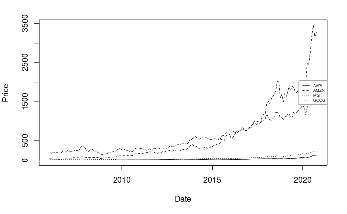

```r
# plotting the data
plot(as.zoo(stocks), screens = 1, lty = 1:4, xlab = "Date", ylab = "Price")
legend("right", c("AAPL", "AMZN", "MSFT", "GOOG"), lty = 1:4, cex = 0.5)
```

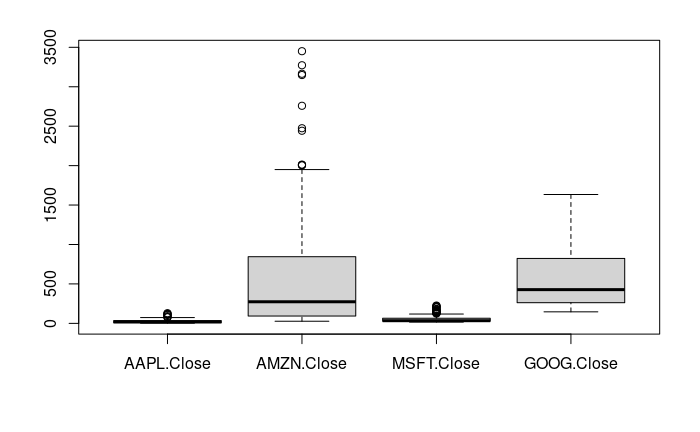

```r
vecst<-data.matrix(as.data.frame(stocks)) #convert xts into matrix

boxplot(vecst) #boxplot of matrix
```

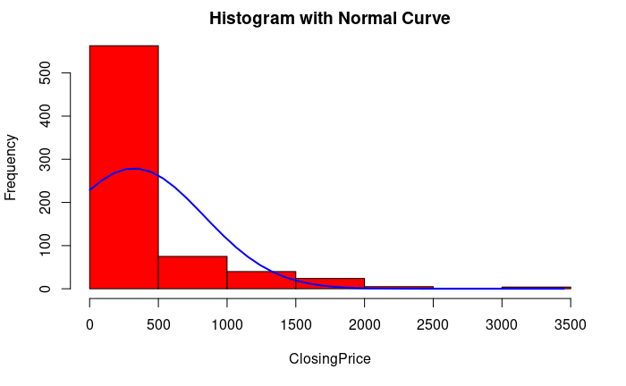

```r
h<-hist(vecst, breaks=10, col="red", xlab="ClosingPrice",
   main="Histogram with Normal Curve")
   xfit<-seq(min(vecst),max(vecst),length=40)
yfit<-dnorm(xfit,mean=mean(vecst),sd=sd(vecst))
yfit <- yfit*diff(h$mids[1:2])*length(vecst)
lines(xfit, yfit, col="blue", lwd=2)
```

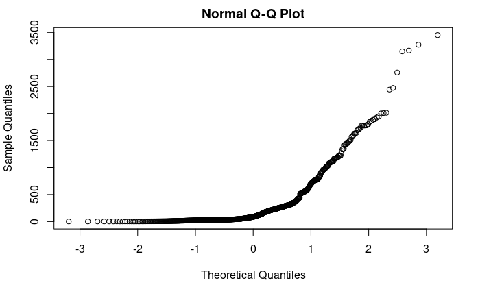

```r
qqnorm(stocks)
```

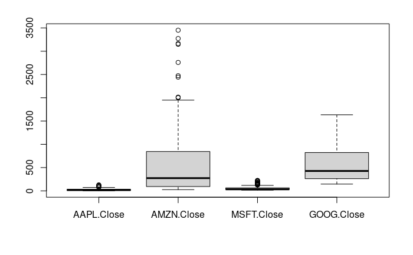

```r
#Get AAPL, AMZN, NFLX, FB STock Prices

AAPL <- tq_get("AAPL", get = "stock.prices", from = "2015-01-01", to = "2019-12-31")

AMZN <- tq_get("AMZN", get = "stock.prices", from = "2015-01-01", to = "2019-12-31")

NFLX <- tq_get("NFLX", get = "stock.prices", from = "2015-01-01", to = "2019-12-31")

FB <- tq_get("FB", get = "stock.prices", from = "2015-01-01", to = "2019-12-31")


# boxplot of matrix
boxplot(vecst)
```

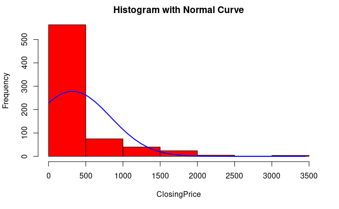

```r
h<-hist(vecst, breaks=10, col="red", xlab="ClosingPrice",
   main="Histogram with Normal Curve")
   xfit<-seq(min(vecst),max(vecst),length=40)
yfit<-dnorm(xfit,mean=mean(vecst),sd=sd(vecst))
yfit <- yfit*diff(h$mids[1:2])*length(vecst)
lines(xfit, yfit, col="blue", lwd=2)
```

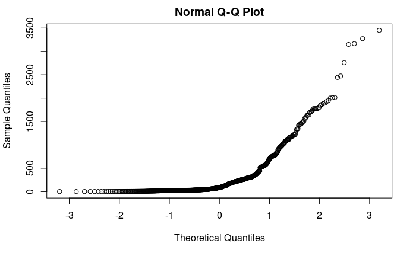

```r
qqnorm(stocks)
```

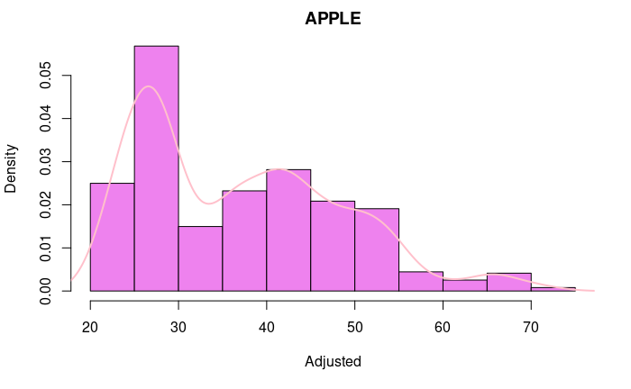

```r
# Histogram (incl. normal density)

hist(AAPL$adjusted, # histogram APPLE
 col="violet", # column color
prob = TRUE, # show densities instead of frequencies
 xlab = "Adjusted",
 main = "APPLE")
lines(density(AAPL$adjusted), # density plot
 lwd = 2, # thickness of line
 col = "pink")
```

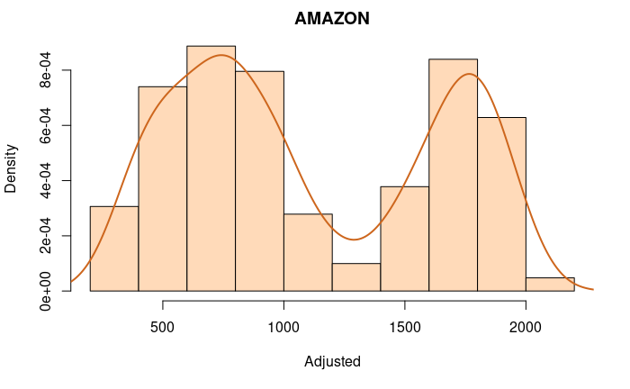

```r
hist(AMZN$adjusted, # histogram AMAZON
 col="peachpuff", # column color
prob = TRUE, # show densities instead of frequencies
 xlab = "Adjusted",
 main = "AMAZON")
lines(density(AMZN$adjusted), # density plot
 lwd = 2, # thickness of line
 col = "chocolate3")
```

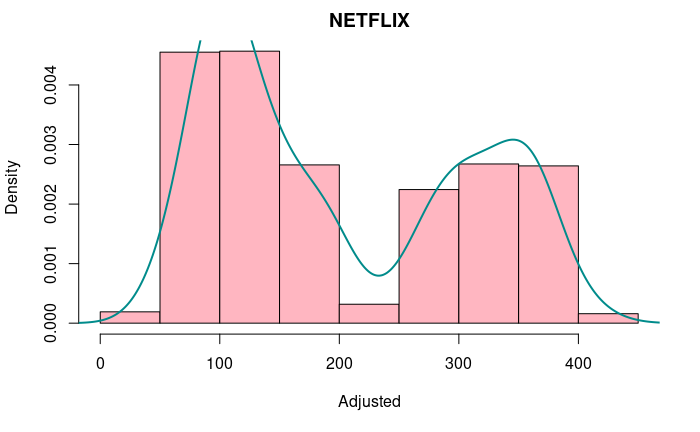

```r
hist(NFLX$adjusted, # histogram NETFLIX
 col="lightpink", # column color
prob = TRUE, # show densities instead of frequencies
 xlab = "Adjusted",
 main = "NETFLIX")
lines(density(NFLX$adjusted), # density plot
 lwd = 2, # thickness of line
 col = "cyan4")
```

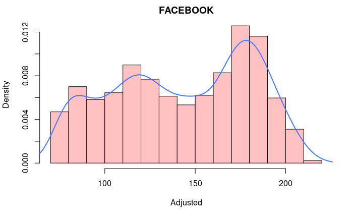

```r
 hist(FB$adjusted, # histogram FACEBOOK
 col="rosybrown1", # column color
prob = TRUE, # show densities instead of frequencies
 xlab = "Adjusted",
 main = "FACEBOOK")
lines(density(FB$adjusted), # density plot
 lwd = 2, # thickness of line
 col = "royalblue1")
```

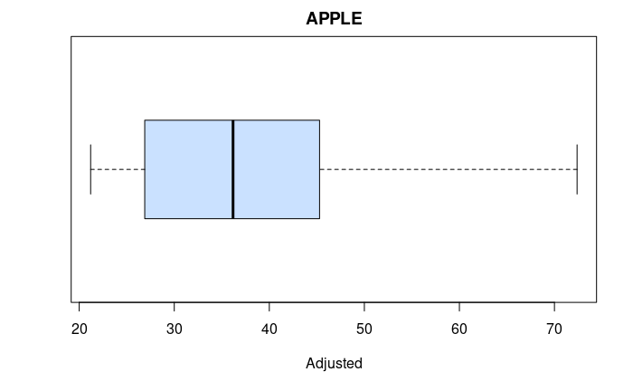

```r
#Box-Plot
boxplot(AAPL$adjusted, main="APPLE", xlab="Adjusted",col="lightsteelblue1", horizontal = TRUE)
```

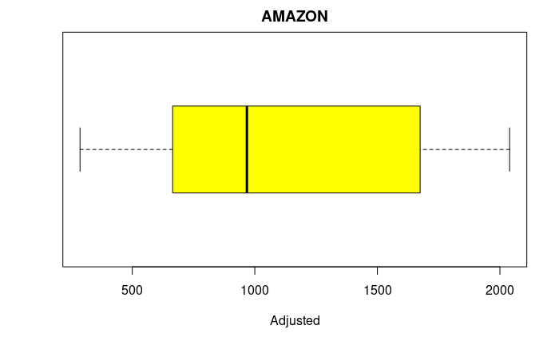

```r
boxplot(AMZN$adjusted, main="AMAZON", xlab="Adjusted",col="yellow", horizontal = TRUE)
```

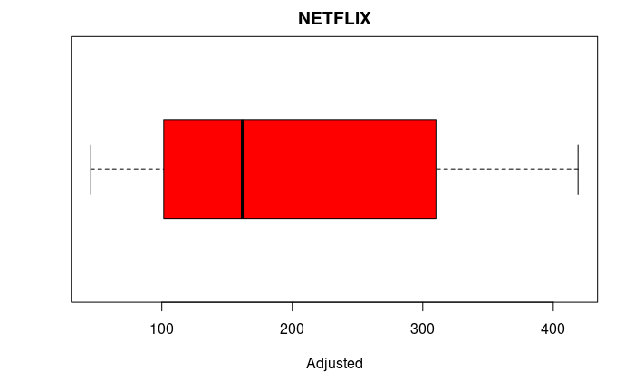

```r
boxplot(NFLX$adjusted, main="NETFLIX", xlab="Adjusted",col="red", horizontal = TRUE)
```

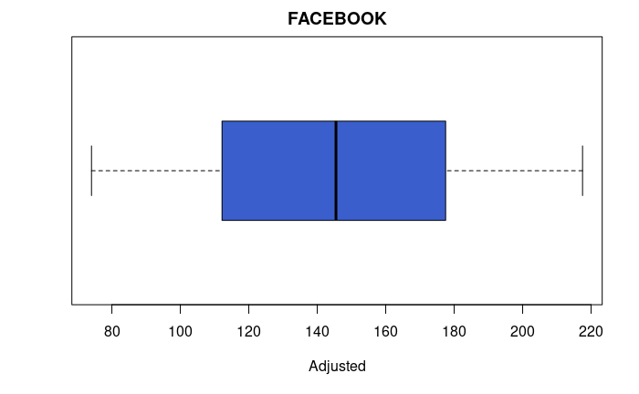

```r
boxplot(FB$adjusted, main="FACEBOOK", xlab="Adjusted",col="royalblue3", horizontal = TRUE)
```

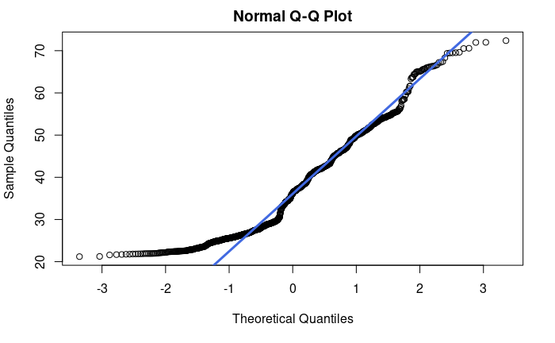

```r
#gg-Plot

qqnorm(AAPL$adjusted)
qqline(AAPL$adjusted,col="royalblue",lwd=3) #to see if normal distribution
```

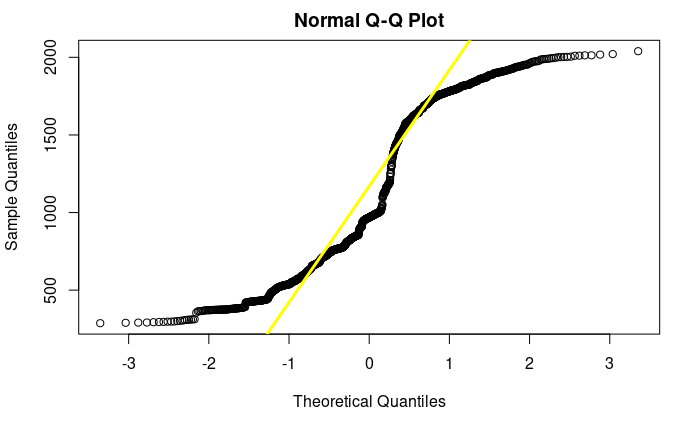

```r
qqnorm(AMZN$adjusted)
qqline(AMZN$adjusted,col="yellow",lwd=3)
```

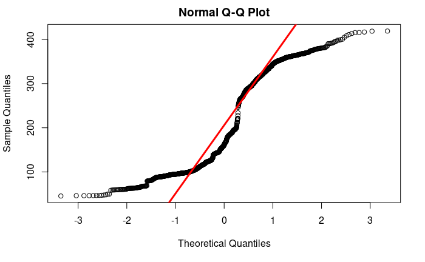

```r
qqnorm(NFLX$adjusted)
qqline(NFLX$adjusted,col="red",lwd=3)
```

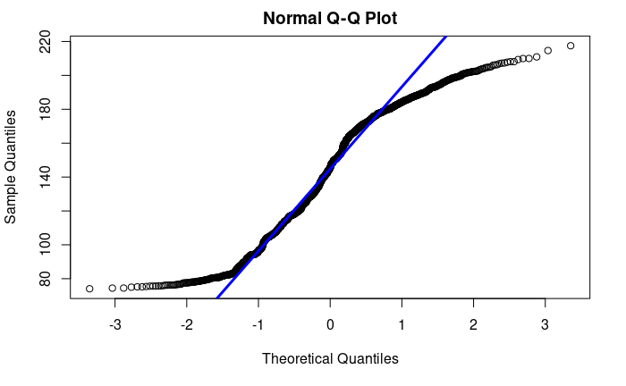

```r
qqnorm(FB$adjusted)
qqline(FB$adjusted,col="blue",lwd=3)
```

# Exercise 4: Statistics

Here you might use all `tidyquant`-vignettes! My shiny-script here might also help you to get an idea: www.riskindex.eu:3838/mci.

### Exercise 4.1 Within securities

For the four securities calculate all interesting statistics (measures of location, dispersion, skewness and kurtosis). Check returns for univariate (and multivariate) normality.

```r
Stocks.raw <- c("MSFT","AAPL","AMZN","GOOG") %>%
    tq_get(get  = "stock.prices", from = "2000-01-01", to   = Sys.Date()) %>%
    group_by(symbol)
Stocks_ret_daily <- Stocks.raw %>%
    tq_transmute(select = adjusted, mutate_fun = periodReturn,
                 period = "daily", col_rename = "return", type="log")
Stocks_ret_monthly <- Stocks.raw %>%
    tq_transmute(select = adjusted, mutate_fun = periodReturn,
                 period = "monthly", col_rename = "return", type="log")

#geometric and arithmetic mean

#monthly

Stocks_ret_monthly %>% summarize(geometric_mean=mean.geometric(return), arithmetic_mean=mean(return)) %>%
          mutate_at(-1, round, 5) %>% t()
```

```
                       [,1]
geometric_mean  0.007386771
arithmetic_mean 0.014550000
```

```r
#daily
Stocks_ret_daily %>% summarize(geometric_mean=mean.geometric(return), arithmetic_mean=mean(return)) %>%
          mutate_at(-1, round, 5) %>% t()
```

```
                        [,1]
geometric_mean  0.0003605938
arithmetic_mean 0.0007000000
```

```r
#Skewness and kurtosis

Stocks_ret_daily %>% summarize(Skewness=skewness(return), "Ex. Kurtosis"=kurtosis(return)) %>%
          mutate_at(-1, round, 3) %>% t()
```

```
                  [,1]
Skewness     -1.006599
Ex. Kurtosis 47.510000
```

```r
#measures of spread
#monthly
Stocks_ret_monthly %>% summarize(Volatility=sd(return), Range=max(return)-min(return), IQR=IQR(return)) %>%
          mutate_at(-1, round, 3) %>% t()
```

```
                [,1]
Volatility 0.1100989
Range      1.3450000
IQR        0.1120000
```

```r
#daily
Stocks_ret_daily %>% summarize(Volatility=sd(return), Range=max(return)-min(return), IQR=IQR(return)) %>%
          mutate_at(-1, round, 3) %>% t()
```

```
                 [,1]
Volatility 0.02526363
Range      1.02700000
IQR        0.02100000
```

```r
#Standard deviation - measures of spread financial risk

#monthly
Stocks_ret_monthly %>% summarize(Semideviation=SemiDeviation(return),
  "VaR(0.05)"=VaR(return,p=0.05), "CVaR(0.05)"=CVaR(return,p=0.05)) %>%
  mutate_at(-1, round, 3) %>% t()
```

```
                     [,1]
Semideviation  0.08340466
VaR(0.05)     -0.17900000
CVaR(0.05)    -0.39800000
```

```r
#daily
Stocks_ret_daily %>% summarize(Semideviation=SemiDeviation(return),
  "VaR(0.05)"=VaR(return,p=0.05), "CVaR(0.05)"=CVaR(return,p=0.05)) %>%
  mutate_at(-1, round, 3) %>% t()
```

```
                     [,1]
Semideviation  0.01809499
VaR(0.05)     -0.02300000
CVaR(0.05)    -0.02300000
```

### Exercise 4.2 Between securities and with index

Plot all securities vis-a-vis the index. Include a regression line and regression information. Can you plot rolling correlations between assets (and/or the index)?

```r
#grouping the 4 securities, getting monthly returns
Ra<-c("AAPL","AMZN","MSFT","GOOG")%>%
tq_get(get="stock.prices",from="2016-12-31",to="2019-12-31")%>%
group_by(symbol)%>%
tq_transmute(select     = adjusted, mutate_fun = periodReturn,period     = "monthly",col_rename = "Ra")

#monthly Returns for the Dow Jones
Rb <- c("DJI") %>%
    tq_get(get  = "stock.prices",from="2016-12-31",to="2019-12-31")  %>%
    tq_transmute(select     = adjusted,
                 mutate_fun = periodReturn,
                 period     = "monthly",
                 col_rename = "Rb")
RaRb <- left_join(Ra, Rb, by = c("date" = "date"))

RaRb %>%
    tq_performance(Ra = Ra, Rb = Rb, performance_fun = table.CAPM)
```

| symbol | ActivePremium | Alpha | AnnualizedAlpha | Beta | Beta- | Beta+ | Correlation | Correlationp-value | InformationRatio | R-squared | TrackingError | TreynorRatio |
| --- | --- | --- | --- | --- | --- | --- | --- | --- | --- | --- | --- | --- |
| AAPL | 0.1083 | 0.0112 | 0.1430 | 0.9337 | 1.8193 | 0.2425 | 0.4091 | 0.0275 | 0.3523 | 0.1674 | 0.3073 | 0.4069 |
| AMZN | 0.3294 | 0.0206 | 0.2768 | 1.5563 | 2.4502 | 1.5197 | 0.6618 | 0.0001 | 1.4575 | 0.4379 | 0.2260 | 0.2237 |
| MSFT | 0.2557 | 0.0183 | 0.2431 | 0.9927 | 1.2711 | 0.5365 | 0.7431 | 0.0000 | 1.5948 | 0.5522 | 0.1604 | 0.3880 |
| GOOG | 0.0546 | 0.0042 | 0.0517 | 1.0723 | 1.1868 | 0.8937 | 0.7335 | 0.0000 | 0.2980 | 0.5380 | 0.1833 | 0.1803 |

```r
#AAPL vs Dow Jones
stock_prices <- c("DJI", "AAPL") %>%
    tq_get(get  = "stock.prices",
         from="2016-12-31",to="2019-12-31") %>%
    group_by(symbol)

stock_pairs <- stock_prices %>%
    tq_transmute(select     = adjusted,
                 mutate_fun = periodReturn,
                 period     = "daily",
                # type       = "log",
                 col_rename = "returns") %>%
    spread(key = symbol, value = returns)
```

[output not shown]

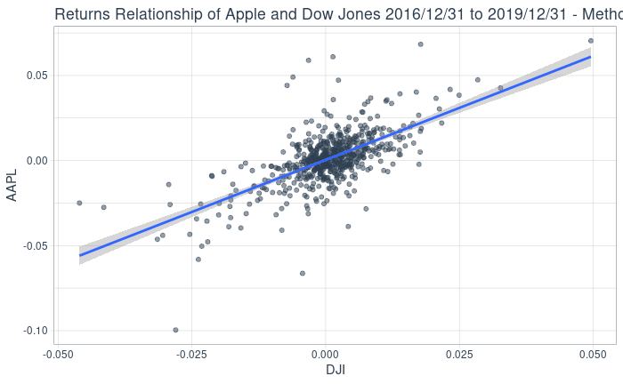

```r
stock_pairs %>%
  ggplot(aes(x = DJI, y = AAPL)) +
    geom_point(color = palette_light()[[1]], alpha = 0.5) +
    geom_smooth(method = "lm") +
    labs(title = "Returns Relationship of Apple and Dow Jones 2016/12/31 to 2019/12/31 - Method: lm") +
    theme_tq()
```

```r
#AMZN vs Dow Jones
stock_prices <- c("DJI", "AMZN") %>%
    tq_get(get  = "stock.prices",
         from="2016-12-31",to="2019-12-31") %>%
    group_by(symbol)

stock_pairs <- stock_prices %>%
    tq_transmute(select     = adjusted,
                 mutate_fun = periodReturn,
                 period     = "daily",
                # type       = "log",
                 col_rename = "returns") %>%
    spread(key = symbol, value = returns)
```

[output not shown]

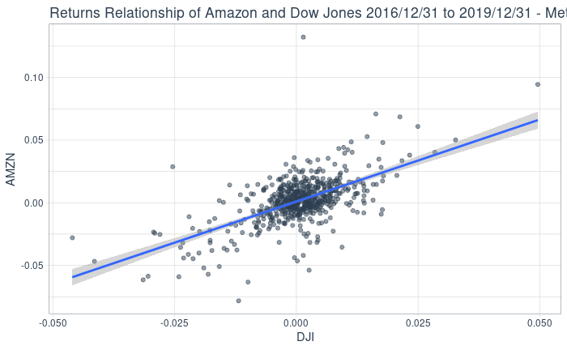

```r
stock_pairs %>%
    ggplot(aes(x = DJI, y = AMZN)) +
    geom_point(color = palette_light()[[1]], alpha = 0.5) +
    geom_smooth(method = "lm") +
    labs(title = "Returns Relationship of Amazon and Dow Jones 2016/12/31 to 2019/12/31 - Method: lm") +
    theme_tq()
```